# R Markdown Advanced Example

Damian Pavlyshyn

4/22/2020

# 1 Chunk options

Sometimes we may want not include the code or outpout of a particular chunk. We can do this using “chunk options” that we include in the `{r <name> <options>}` part of the chunk opening.

`echo=FALSE` will suppress code from the output, but will display the output. This is useful, for example, when you have a complicated plotting specification that isn’t relevant to the analysis itself. However, **please do not use this option in your final project!** I want to see all your code!

```
## [1] 2
```

We can also suppress both the code and the output with the `include=FALSE` option. In the following invisivle chunk, I set the variable `v`.

Now I can access the variable even though the code that set it doesn’t appear in the output file.

```
## [1] 1 2 3
```

Often when you run R code, it prints a bunch of information in addition to the actual output. By default, this is included in the output document, but it can be suppressed using `message=FALSE`.

```
## # A tibble: 7 x 7
##   Name      Year  English  Math Science History Spanish
##   <chr>     <chr>   <dbl> <dbl>   <dbl>   <dbl>   <dbl>
## 1 Maedhros  Sen        60    96      80      56      77
## 2 Maglor    Sen        66    55      56      64      77
## 3 Celegorm  Jun        92    63      70      62      98
## 4 Caranthir Jun        80    76      89      55      40
## 5 Curufin   Sen        80    80      82      48      50
## 6 Amrod     Sen        58    52      79      90      61
## 7 Amras     Jun        81    64      90      71      72
```

The last very useful options are the `fig.height` and `fig.width` options, wihch control the size of any output figures.

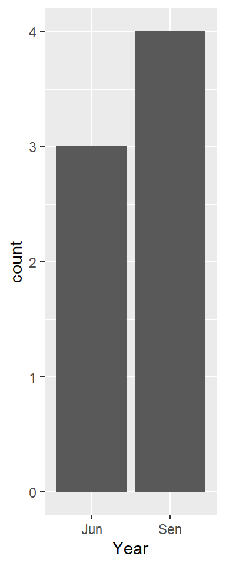

## 1.1 The setup chunk

We can set options for all chunks in the document with a sepcial “setup” chunk at the beginning of the document. This document’s setup chunk also contains a line that sets the root directory, which is preferrable to using `setwd()` for some technical reasons.

# 2 Header options

We can specify a lot of interesting formatting options in the header, as demonstrated in this document’s header. In this case, we’ve numbered the sections and added an automatic table of contents.

A good summary of available and exotic header options can be found [here](https://bookdown.org/yihui/rmarkdown/html-document.html).